# StockResearch

Gabriel Foix

2021-01-30

Buy Quality at the a good momentum and get rid of the fishy stocks on time. That's all.

### Define candidates

Download all info needed applying the following filters:

### Factor 1: Quality

1. Healthy debts: A company shoud generate cash in order to repay its debt. The **Free Cash Flow to Debt** ratio is a good indicator of how quick a company pays back its debt. The lower this ratio the better.

FCF2D = $\frac{Debt}{Free Cash Flow}$

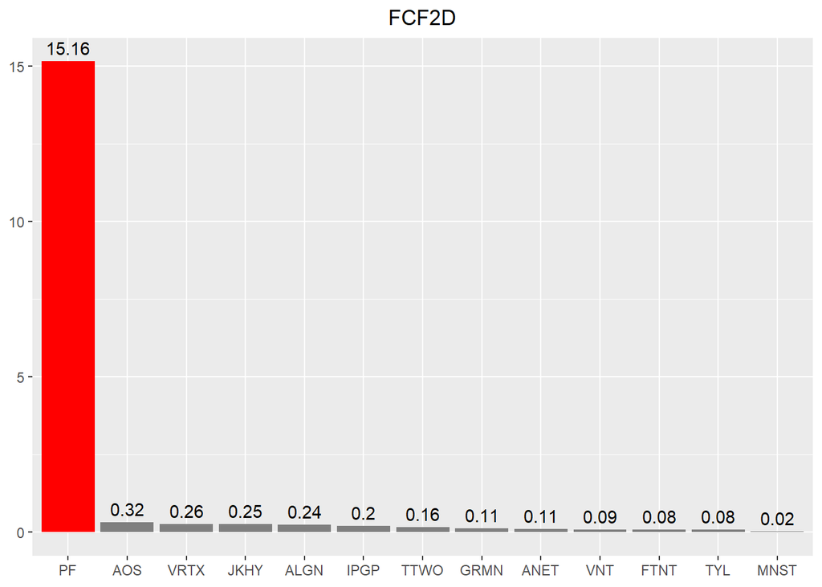

2. Profitability: ROA

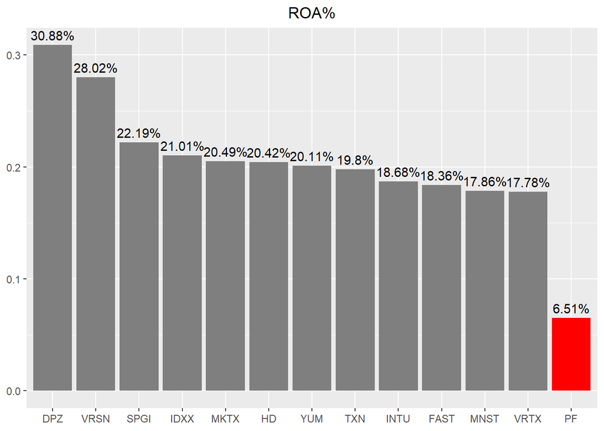

3. High Margin: We look for companies that generate free cash flow compare to its price. The **Free Cash Flow to Entreprise Value** ratio tells us how many years of cash flow would be needed to the return the 100% of the investment. Again, the lower, the better. Values bellow 1 would mean "free lunch".

FCF2EV = $\frac{EV}{Free Cash Flow}$

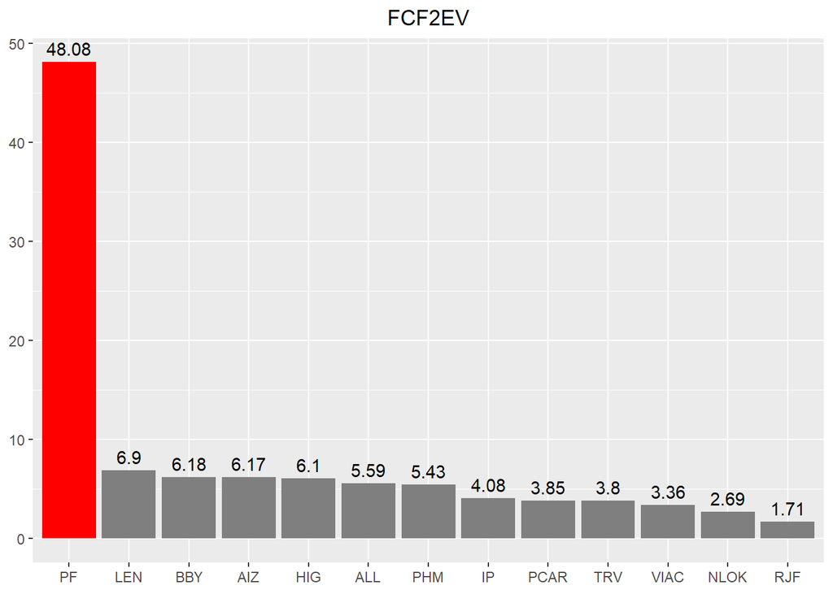

#### Download Historical Data

Download only stocks not filtered previously

### Value touch

Filter out stocks with PER > 40

Report Candidates

Filter Summary

| Filter | NStocks |
| --- | --- |
| Initial | 505 |
| ROA | 421 |
| FCF | 364 |
| Hist1Y | 359 |
| PER | 229 |

### Factor 2: Momentum

Don't hold onto a stock simply because it is high quality. So called quality stocks have cycles too. Stan Weinstein (page 177)

Generic Intermediate-Term Momentum Based on Gray-Vogel (page 80)

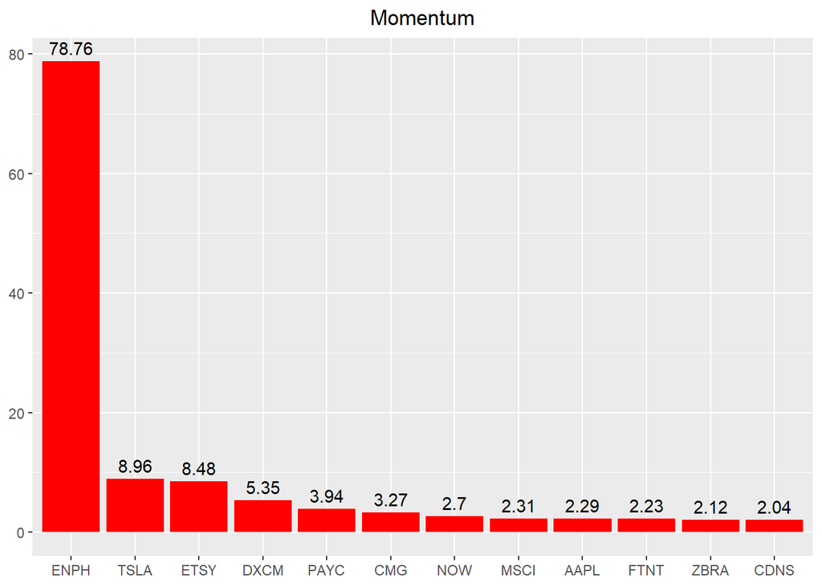

### Factor 3: Timing Signal

Sell Signal - Pr < 1% SMA 30 weeks and slope negative (< -0.2)  
Buy Signal - 109% * SMA30 < Pr > SMA 30 and slope positive (> 0.2)  
Hold Signal - Neither Buy nor Sell

#### Calc Market Cap

Using free float shares

### Summary

Summary

| Ticker | Signal | Quality | Momentum | Final_rank | PER | MCap |
| --- | --- | --- | --- | --- | --- | --- |
| AAPL | BUY | 356.0 | 351 | 394.5 | 35.790618 | 2.213098e+12 |
| TGT | BUY | 369.5 | 337 | 393.0 | 24.031038 | 9.045289e+10 |
| TER | BUY | 357.5 | 341 | 392.0 | 26.514019 | 1.877571e+10 |
| COST | HOLD | 389.0 | 308 | 391.0 | 36.183777 | 1.556595e+11 |
| FAST | HOLD | 380.0 | 299 | 384.0 | 30.597316 | 2.607725e+10 |
| SPGI | SELL | 377.5 | 294 | 382.0 | 31.773078 | 7.614969e+10 |
| ACN | HOLD | 397.0 | 273 | 379.5 | 29.778434 | 1.531844e+11 |
| HOLX | HOLD | 396.0 | 274 | 379.5 | 15.143400 | 2.041067e+10 |
| SWKS | HOLD | 405.0 | 263 | 377.0 | 26.268819 | 2.799999e+10 |
| LLY | HOLD | 340.5 | 324 | 376.0 | 34.026505 | 1.548305e+11 |
| HCA | BUY | 387.5 | 270 | 375.0 | 16.428715 | 4.287437e+10 |
| PWR | BUY | 354.5 | 296 | 373.0 | 26.080681 | 9.668199e+09 |
| CDNS | BUY | 296.0 | 348 | 371.0 | 33.806067 | 3.583154e+10 |
| KLAC | HOLD | 307.0 | 336 | 370.0 | 34.063489 | 4.316655e+10 |
| ODFL | HOLD | 338.5 | 304 | 369.0 | 36.777251 | 1.987217e+10 |
| PG | HOLD | 357.5 | 282 | 368.0 | 24.227137 | 3.153573e+11 |
| GRMN | BUY | 329.0 | 309 | 367.0 | 21.561855 | 1.633950e+10 |
| LOW | HOLD | 381.0 | 254 | 366.0 | 23.603057 | 1.221350e+11 |
| TSCO | HOLD | 330.0 | 298 | 363.0 | 22.216302 | 1.642852e+10 |
| BBY | HOLD | 403.0 | 214 | 361.0 | 16.583359 | 2.520133e+10 |
| TXN | BUY | 361.0 | 255 | 360.0 | 27.763070 | 1.520780e+11 |
| EXPD | HOLD | 384.0 | 231 | 359.0 | 24.148907 | 1.504993e+10 |
| CHD | HOLD | 315.5 | 293 | 357.5 | 27.060897 | 2.087829e+10 |
| MSFT | BUY | 276.5 | 332 | 357.5 | 34.584763 | 1.723862e+12 |
| CTAS | HOLD | 288.5 | 319 | 356.0 | 35.683679 | 2.857472e+10 |
| PHM | HOLD | 407.0 | 195 | 353.0 | 8.397683 | 1.133827e+10 |
| CLX | HOLD | 366.0 | 234 | 352.0 | 23.281094 | 2.630711e+10 |
| MCO | HOLD | 306.0 | 292 | 350.5 | 27.720980 | 4.979774e+10 |
| VRTX | SELL | 399.0 | 198 | 348.0 | 22.450020 | 5.948251e+10 |
| AMAT | HOLD | 324.0 | 271 | 347.0 | 24.663265 | 8.797713e+10 |

[output cut: 199 more lines]

Save output in template